# UsersGuide

2022-06-22

## Basic usage

ifCNVR stands for **i**solation **f**orest based **C**opy **N**umber **V**ariation detection.

Its usage is meant to be approachable for entry-level users.

```r
library(ifCNVRR)

pathToBam <- "/path/to/bam/files/"
pathToBed <- "/path/to/bed/file.bed"
pathToBedtools <- "/path/to/bedtools/"
outputPath <- "/path/to/html/report.html"

# After installing bedtools (https://bedtools.readthedocs.io/en/latest/content/installation.html),
# type `which bedtools` in your console to get the pathToBedtools

# Create reads matrix
readsMatrix <- CreateReadsMatrix(pathToBam, pathToBed, pathToBedtools)

# Detect CNV positive samples
CNVpos <- abSamples(readsMatrix)

# Detect CNV positive targets
CNVtar <- abTargets(readsMatrix, CNVpos)

# Create the results table
resTable <- calculateScore(readsMatrix, CNVpos, CNVtar)

# Generate the html report
generateReport(outputFile = outputPath, readsMatrix, resTable, CNVpos)
```

**ifCNVR** input: - the aligned sequences (.bam or .cram files and their associated indexes) - the genomic coordinates of the region of interest (a .bed file, see http://genome.cse.ucsc.edu/FAQ/FAQformat.html#format1 and below for more information).

**ifCNVR** ouput: - An html report

Some **BED file** informations:

The BED (Browser Extensible Data) format is a text file format used to store genomic regions as coordinates and associated annotations. The data are presented in the form of columns separated by spaces or tabs. This format was developed during the Human Genome Project and then adopted by other sequencing projects (source: wikipedia). For targeted sequencing, it is supposed to be provided by the vendor.

As it is of important for **ifCNVR** let’s see some key points: - the BED file must have (at least) 4 columns, the three first are the cooridnates of the baited genomic regions and the forth one is a character describing these regions. - The forth column is the name of the targeted region and it must be set carefuly as it will be used to compute the localization score (see the **Resolution paragraph**)

If you don’t have the capture regions BED file, but you do know which commercial exome capture kit was used to prepare your samples, you might find the file you need in Astra-Zeneca’s reference data repository. Otherwise, try searching the vendor’s website or contacting their customer support for the right file.

## Interpretation of the html report:

[figure not shown]

- The 1st column is the run name (defult is ifCNVR, but it can be specified with the -r flag).
- The 2nd column is the sample name (by default the table is sorted by this column).
- The 3rd column is the name of the region (here a gene).
- The 4th column is the reads ratio (1<reads_ratio<2 gain, reads_ratio>2 amplification, reads_ratio<1 loss).
- The 5th column is the localization score.

The user can click on each line to visualize a graph of the normalized log ratio for the region of interest where each point represents a target.

[figure not shown]

## Exploring different scenarios

### Changing the resolution

The resolution of ifCNVR is set in the .bed file. So, by changing he 4th column of the .bed file the user can easily change the resolution of ifCNVR. ifCNVR splits this name on the “-” character and regroups whats on the left of it as the **region of interest**.

**A**:

```
chr4    55155143    55155306    4q12-PDGFRA-E21-STA101436   0   +   55155159    55155287    113,255,0
chr4    55156535    55156697    4q12-PDGFRA-E22-STA101437   0   +   55156551    55156681    113,255,0
chr4    55161233    55161388    4q12-PDGFRA-E23-STA101438   0   +   55161253    55161366    113,255,0
chr4    55524153    55524297    4q12-KIT-E1-STA101439   0   +   55524170    55524281    85,255,0
chr4    55561669    55561832    4q12-KIT-E2-STA101440   0   +   55561686    55561810    85,255,0
chr4    55564526    55564689    4q12-KIT-E3-STA101441   0   +   55564544    55564675    85,255,0
```

**B**:

The user can increase the resolution by changing the separating character. For example:

```
chr4    55155143    55155306    4q12_PDGFRA-E21-STA101436   0   +   55155159    55155287    113,255,0
chr4    55156535    55156697    4q12_PDGFRA-E22-STA101437   0   +   55156551    55156681    113,255,0
chr4    55161233    55161388    4q12_PDGFRA-E23-STA101438   0   +   55161253    55161366    113,255,0
chr4    55524153    55524297    4q12_KIT-E1-STA101439   0   +   55524170    55524281    85,255,0
chr4    55561669    55561832    4q12_KIT-E2-STA101440   0   +   55561686    55561810    85,255,0
chr4    55564526    55564689    4q12_KIT-E3-STA101441   0   +   55564544    55564675    85,255,0
```

Using this .bed file, the resolution will be at the gene level, meaning the 3 first targets will be considered as belonging to the same region (4q12-PDGFRA) and the 3 last to another **region of interest** (4q12-KIT) in the calculus of the localisation score and in the output.

**C**:

Again, in this example, the user can increase the resolution by changing the separating character:

```
chr4    55155143    55155306    4q12_PDGFRA_E21-STA101436   0   +   55155159    55155287    113,255,0
chr4    55156535    55156697    4q12_PDGFRA_E22-STA101437   0   +   55156551    55156681    113,255,0
chr4    55161233    55161388    4q12_PDGFRA_E23-STA101438   0   +   55161253    55161366    113,255,0
chr4    55524153    55524297    4q12_KIT_E1-STA101439   0   +   55524170    55524281    85,255,0
chr4    55561669    55561832    4q12_KIT_E2-STA101440   0   +   55561686    55561810    85,255,0
chr4    55564526    55564689    4q12_KIT_E3-STA101441   0   +   55564544    55564675    85,255,0
```

Using this .bed file, the resolution will be at the exon level, meaning each target will be considered as belonging to a single **region of interest** (ie 4q12-PDGFRA-E21).

#### Localisation score

Specific regions of biological significance (gene or exon) can be covered by several targets. In the event that a region is altered, all the targets in the region should be modified. By contrast, if only one target in the region is modified, it is likely to be a FP. We integrated this reasoning to develop a localisation score in order to reduce the number of FPs. The localisation score depends on the number of modified targets in the region, the number of targets in the region and the total number of targets in the panel. A semi-open log scale incorporating the ratio of modified targets in the region was chosen. It is calculated as follows:

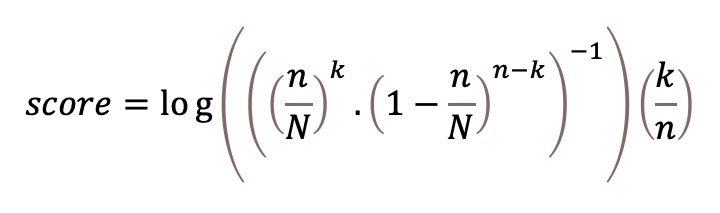

*whith k the number of modified targets on the region, n the number of targets on the region, N the total number of targets.*

This score is thresholded to keep only the significant regions, by default the threshold is 10. However, it can be useful for the user to change that threshold regarding the design of the experiment.

For example, in the first case (**A**), 6 targets are on the same region, this means that with a panel of 1000 targets the score will range from 0.86 to 30.7 depending on the number of outlying targets detected:

| Number of outlying targets | Localisation score |
| --- | --- |
| 0 | 0 |
| 1 | 0.87 |
| 2 | 3.42 |
| 3 | 7.68 |
| 4 | 13.65 |
| 5 | 21.32 |
| 6 | 30.7 |

With a score threshold (-sT) at 10 ifCNVR will consider the regoin significantly altered if 4 targets are.

In the second case (**B**), 3 targets are in the same region, for the same panel (1000 targets) the score will range from 1.94 to 17.42:

| Number of outlying targets | Localisation score |
| --- | --- |
| 0 | 0 |
| 1 | 1.94 |
| 2 | 7.75 |
| 3 | 17.42 |

Which means that the region will be considered altered if all three regions are detected as outliers.

In the third case (**C**), there is only one target per region, meaning that the localisation score will be either 0 either 6.91.

ifCNVR will never consider the regions as altered if the user doesn’t change the score threshold in the calculateScore() function.

The command in this case will be:

```r
resTable <- calculateScore(readsMatrix, CNVpos, CNVtar, thrScore = 6)
```

Then, if an exon is detected as an outlier it will be considered as altered.

Therefore, there is no longer a control of false positives when looking for CNVs on regions covered with only one target (typically exons in capture experiments). To recover some control over the false positive rate, the user can change the contamination parameters.